# Exploring Antarctic Marine Species with `worrms`

## 12.3 `wm_attr_data()` — Trait data for a specific taxon

```r
# Attributes for Antarctic krill
krill_attrs <- wm_attr_data(236217)
krill_attrs |> glimpse()
```

```
#> Rows: 2
#> Columns: 10
#> $ AphiaID           <int> 236217, 236217
#> $ measurementTypeID <int> 23, 23
#> $ measurementType   <chr> "Species importance to society", "Species importance…
#> $ measurementValue  <chr> "FAO-ASFIS: Species for Fishery Statistics Purposes"…
#> $ source_id         <int> 197354, 127093
#> $ reference         <chr> "FAO Fishery Fact Sheets Collections: Aquatic Scienc…
#> $ qualitystatus     <chr> "unreviewed", "unreviewed"
#> $ AphiaID_Inherited <int> 236217, 236217
#> $ CategoryID        <int> 13, 13
#> $ children          <list> [<data.frame[1 x 10]>], [<data.frame[1 x 10]>]
```

```r
# Vectorised: get traits for several taxa at once
ids_to_check <- unlist(wm_name2id_(c("Euphausia superba",
                                      "Dissostichus eleginoides",
                                      "Notothenia coriiceps")))
attr_list <- wm_attr_data_(ids_to_check)

# Bind and summarise
attr_all <- bind_rows(attr_list)
attr_all |>
  select(AphiaID, measurementType, measurementValue) |>
  head(20)
```

```
#> # A tibble: 10 × 3
#>    AphiaID measurementType                                  measurementValue
#>      <int> <chr>                                            <chr>
#>  1  236217 Species importance to society                    FAO-ASFIS: Species …
#>  2  236217 Species importance to society                    IUCN Red List
#>  3  234700 Species importance to society                    FAO-ASFIS: Species …
#>  4  234700 Body size                                        215
#>  5  234700 Body size                                        70
#>  6  234700 Species exhibits underwater soniferous behaviour Does not or is unli…
#>  7  234679 Species importance to society                    FAO-ASFIS: Species …
#>  8  234679 Body size                                        62
#>  9  234679 Body size                                        50
#> 10  234679 Species exhibits underwater soniferous behaviour Does not or is unli…
```

## 12.4 `wm_attr_aphia()` — All taxa that have a given attribute

```r
# Get AphiaIDs of taxa that have any attribute from category 1 (IUCN Red List)
# (returns up to 50 per page — the API is paginated)
taxa_with_fg <- wm_attr_aphia(id = 1)
head(taxa_with_fg, 10)
```

```
#> # A tibble: 10 × 2
#>    AphiaID Attributes
#>      <int> <list>
#>  1  100801 <df [1 × 10]>
#>  2  100807 <df [1 × 10]>
#>  3  100822 <df [1 × 10]>
#>  4  100823 <df [1 × 10]>
#>  5  100830 <df [1 × 10]>
#>  6  100831 <df [1 × 10]>
#>  7  100870 <df [1 × 10]>
#>  8  100888 <df [1 × 10]>
#>  9  100906 <df [1 × 10]>
#> 10  100985 <df [1 × 10]>
```

# 13 Full use-case — Antarctic fish biodiversity with WoRMS + GBIF

Here we bring everything together. We will:

## 13.1 Step 1 — Find the Notothenioidei subtree in WoRMS

```r
# AphiaID for suborder Notothenioidei
notothenioidei_id <- wm_name2id("Notothenioidei")
notothenioidei_id
```

```
#> [1] 151728
```

```r
# Classification to confirm position
wm_classification(notothenioidei_id) |> select(rank, scientificname)
```

```
#> # A tibble: 10 × 2
#>    rank        scientificname
#>    <chr>       <chr>
#>  1 Kingdom     Animalia
#>  2 Phylum      Chordata
#>  3 Subphylum   Vertebrata
#>  4 Infraphylum Gnathostomata
#>  5 Parvphylum  Osteichthyes
#>  6 Gigaclass   Actinopterygii
#>  7 Superclass  Actinopteri
#>  8 Class       Teleostei
#>  9 Order       Perciformes
#> 10 Suborder    Notothenioidei
```

```r
# Direct children (families) — look up ID dynamically
notothenioidei_id <- wm_name2id("Notothenioidei")

notothenioidei_families <- tryCatch(
  wm_children(notothenioidei_id),
  error = function(e) {
    message("wm_children() returned no content or errored: ", conditionMessage(e))
    tibble()
  }
)
notothenioidei_families |> select(AphiaID, scientificname, rank)
```

```
#> # A tibble: 9 × 3
#>   AphiaID scientificname   rank
#>     <int> <chr>            <chr>
#> 1  151398 Artedidraconidae Family
#> 2  151405 Bathydraconidae  Family
#> 3  151403 Bovichtidae      Family
#> 4  234518 Channichthyidae  Family
#> 5 1517588 Eleginopidae     Family
#> 6  267021 Eleginopsidae    Family
#> 7  151397 Harpagiferidae   Family
#> 8  151404 Nototheniidae    Family
#> 9  267029 Pseudaphritidae  Family
```

```r
# For each family, get all species (rank 220)
# We use wm_records_rank_ (vectorised) where possible
family_ids <- notothenioidei_families |>
  filter(rank == "Family") |>
  pull(AphiaID)

# Retrieve species per family — wrap in purrr for safe iteration
species_list <- map(family_ids, function(fid) {
  tryCatch(
    wm_records_rank(220, id = fid),
    error = function(e) NULL
  )
})

# Name the list by family
names(species_list) <- notothenioidei_families |>
  filter(rank == "Family") |>
  pull(scientificname)

# Bind into one data frame
notothenioidei_spp <- bind_rows(species_list, .id = "family") |>
  filter(status == "accepted")

cat("Total accepted Notothenioidei species in WoRMS:", nrow(notothenioidei_spp), "\n")
```

```
#> Total accepted Notothenioidei species in WoRMS: 124
```

```r
notothenioidei_spp |>
  count(family, name = "n_species") |>
  arrange(desc(n_species)) |>
  kbl(caption = "Accepted species per Notothenioidei family") |>
  kable_styling(bootstrap_options = c("striped", "condensed"), full_width = FALSE)
```

Accepted species per Notothenioidei family

| family | n_species |
| --- | --- |
| Artedidraconidae | 37 |
| Channichthyidae | 25 |
| Bathydraconidae | 18 |
| Nototheniidae | 18 |
| Harpagiferidae | 12 |
| Bovichtidae | 11 |
| Pseudaphritidae | 2 |
| Eleginopidae | 1 |

## 13.2 Step 2 — Retrieve GBIF occurrences south of 60°S

```r
# Get accepted scientific names to pass to GBIF
target_species <- notothenioidei_spp |>
 # slice_head(n = 20) |>   # limit to 20 spp for demo (remove slice_head for full run)
  pull(scientificname)

# Download occurrences from GBIF via occ_search()
gbif_results <- map(target_species, function(sp) {
  tryCatch(
    occ_search(
      scientificName = sp,
      decimalLatitude = "-90,-60",   # south of 60°S
      hasCoordinate  = TRUE,
      limit          = 200, # limit to 200 records per species for demo
      fields         = c("name", "decimalLatitude", "decimalLongitude",
                         "year", "datasetName", "species")
    )$data,
    error = function(e) NULL
  )
})

names(gbif_results) <- target_species
gbif_df <- bind_rows(gbif_results) |>
  filter(!is.na(decimalLatitude), !is.na(decimalLongitude))

cat("Total GBIF occurrence records retrieved:", nrow(gbif_df), "\n")
```

```
#> Total GBIF occurrence records retrieved: 7224
```

## 13.3 Step 3 — Join WoRMS metadata onto GBIF records

```r
# Get WoRMS AphiaIDs for the same species names
worms_lookup <- notothenioidei_spp |>
  filter(scientificname %in% target_species) |>
  select(scientificname, AphiaID, family, isMarine, isExtinct, citation)

# Join
gbif_enriched <- gbif_df |>
  rename(scientificname = species) |>
  left_join(worms_lookup, by = "scientificname")

glimpse(gbif_enriched)
```

```
#> Rows: 7,224
#> Columns: 10
#> $ scientificname   <chr> "Artedidraco glareobarbatus", "Artedidraco glareobarb…
#> $ decimalLatitude  <dbl> -76.02880, -76.02880, -76.04286, -61.75290, -62.46050…
#> $ decimalLongitude <dbl> 168.4050, 168.4050, 168.3702, -52.0085, -56.0943, -53…
#> $ year             <int> 1998, 1998, NA, 2008, 2004, 2004, 2003, 2002, 1995, 1…
#> $ datasetName      <chr> "NMNH Extant Biology", "NMNH Extant Biology", NA, NA,…
#> $ AphiaID          <int> 279404, 279404, 279404, 234734, 234734, 234734, 23473…
#> $ family           <chr> "Artedidraconidae", "Artedidraconidae", "Artedidracon…
#> $ isMarine         <int> 1, 1, 1, 1, 1, 1, 1, 1, 1, 1, 1, 1, 1, 1, 1, 1, 1, 1,…
#> $ isExtinct        <int> NA, NA, NA, NA, NA, NA, NA, NA, NA, NA, NA, NA, NA, N…
#> $ citation         <chr> "Froese, R. and D. Pauly. Editors. (2026). FishBase. …
```

## 13.4 Step 4 — Retrieve WoRMS trait data and join

```r
# Get AphiaIDs
focal_ids <- worms_lookup$AphiaID

# Fetch trait data (may take a moment)
trait_list <- map(focal_ids, function(aid) {
  tryCatch(wm_attr_data(aid), error = function(e) NULL)
})
names(trait_list) <- focal_ids

trait_df <- bind_rows(trait_list, .id = "AphiaID") |>
  mutate(AphiaID = as.integer(AphiaID)) |>
  filter(measurementType %in% c("Functional group", "IUCN Red List Category",
                                 "Body size", "Diet"))

# Pivot wider for easy use
trait_wide <- trait_df |>
  select(AphiaID, measurementType, measurementValue) |>
  distinct() |>
  pivot_wider(names_from = measurementType, values_from = measurementValue,
              values_fn = \(x) paste(unique(x), collapse = "; "))

# Final enriched species table
species_enriched <- worms_lookup |>
  left_join(trait_wide, by = "AphiaID")

kbl(species_enriched |> select(scientificname,`Body size`),
    caption = "Notothenioidei species with WoRMS Body Size") |>
  kable_styling(bootstrap_options = c("striped", "hover", "condensed"), full_width = FALSE)
```

Notothenioidei species with WoRMS Body Size

| scientificname | Body size |
| --- | --- |
| Artedidraco glareobarbatus | NA |
| Artedidraco longibarbatus | NA |
| Artedidraco mirus | 12.5 |
| Artedidraco orianae | 15.1 |
| Artedidraco shackletoni | 14.6 |
| Dolloidraco longedorsalis | 13.7 |
| Histiodraco velifer | 19.2 |
| Neodraco lonnbergi | 11 |
| Neodraco skottsbergi | 10 |
| Pogonophryne albipinna | 3.75 |
| Pogonophryne barsukovi | 25 |
| Pogonophryne bellingshausenensis | 23.4 |
| Pogonophryne brevibarbata | 26.7; 26.2 |
| Pogonophryne cerebropogon | 25 |
| Pogonophryne dewitti | 6.7 |
| Pogonophryne eakini | 19.4; 17.7 |
| Pogonophryne favosa | NA |
| Pogonophryne fusca | 13.8 |
| Pogonophryne immaculata | 25 |
| Pogonophryne lanceobarbata | 25 |
| Pogonophryne macropogon | 34 |
| Pogonophryne maculiventrata | NA |
| Pogonophryne marmorata | 21 |
| Pogonophryne mentella | NA |
| Pogonophryne neyelovi | 35.5; 35 |
| Pogonophryne orangiensis | NA |
| Pogonophryne pallida | NA |
| Pogonophryne pavlovi | NA |
| Pogonophryne permitini | 21 |
| Pogonophryne platypogon | 8.05 |

[output cut: 94 more lines]

## 13.5 Step 5 — Visualise

### 13.5.1 Occurrence map — south polar projection

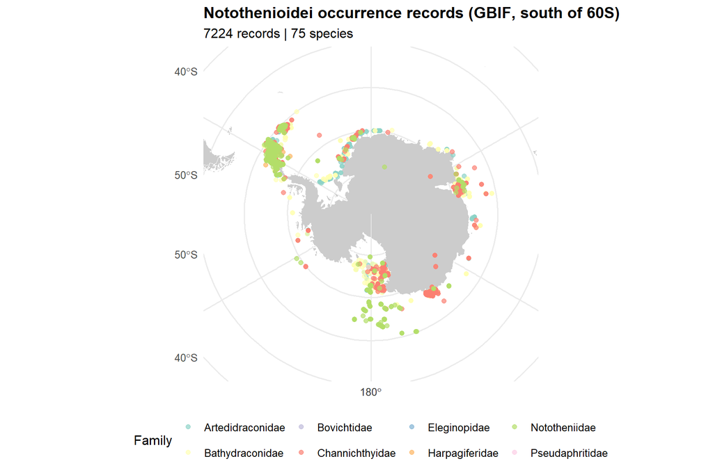

GBIF occurrences of Notothenioidei south of 60°S

```r
world <- ne_countries(scale = "medium", returnclass = "sf")

gbif_sf <- st_as_sf(gbif_enriched,
                    coords = c("decimalLongitude", "decimalLatitude"),
                    crs = 4326)

ggplot() +
  geom_sf(data = st_transform(world, 3031),
          fill = "grey80", colour = "white", linewidth = 0.15) +
  geom_sf(data = st_transform(gbif_sf, 3031),
          aes(colour = family),
          alpha = 0.7, size = 1.8) +
  coord_sf(crs = 3031,
           xlim = c(-4000000, 4000000),
           ylim = c(-4000000, 4000000)) +
  scale_colour_brewer(palette = "Set3", name = "Family") +
  labs(title = "Notothenioidei occurrence records (GBIF, south of 60S)",
       subtitle = paste0(nrow(gbif_enriched), " records | ",
                         n_distinct(gbif_enriched$scientificname), " species"),
       x = NULL, y = NULL) +
  theme_minimal(base_size = 12) +
  theme(legend.position = "bottom",
        plot.title = element_text(face = "bold"))
```

### 13.5.2 Species richness per family

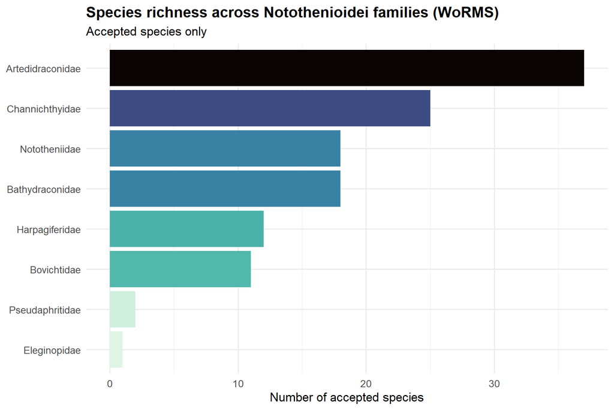

Species richness per Notothenioidei family

```r
notothenioidei_spp |>
  count(family, name = "n_species") |>
  mutate(family = fct_reorder(family, n_species)) |>
  ggplot(aes(x = n_species, y = family, fill = n_species)) +
  geom_col(show.legend = FALSE) +
  scale_fill_viridis_c(option = "mako", direction = -1) +
  labs(title    = "Species richness across Notothenioidei families (WoRMS)",
       subtitle = "Accepted species only",
       x = "Number of accepted species", y = NULL) +
  theme_minimal(base_size = 13) +
  theme(plot.title = element_text(face = "bold"))
```

### 13.5.3 Occurrence records per decade

[figure not shown]

GBIF records per decade for focal Notothenioidei

```r
gbif_enriched |>
  filter(!is.na(year)) |>
  mutate(decade = (year %/% 10) * 10) |>
  count(decade, family) |>
  ggplot(aes(x = decade, y = n, fill = family)) +
  geom_col() +
  scale_fill_brewer(palette = "Set3", name = "Family") +
  labs(title    = "GBIF sampling effort through time — Notothenioidei",
       x = "Decade", y = "Number of occurrence records") +
  theme_minimal(base_size = 13) +
  theme(legend.position = "bottom",
        plot.title = element_text(face = "bold"))
```

# 14 Quick-reference cheat sheet

worrms function cheat sheet

| Function | Purpose | Vectorised version |
| --- | --- | --- |
| wm_name2id() | Scientific name → AphiaID | wm_name2id_() |
| wm_id2name() | AphiaID → scientific name | wm_id2name_() |
| wm_record() | Full AphiaRecord for one ID | wm_record_() |
| wm_records_name() | Search by name (fuzzy optional) | — |
| wm_records_names() | Multiple names → list of records | — |
| wm_records_taxamatch() | TAXAMATCH fuzzy matching | — |
| wm_records_common() | Search by vernacular name | wm_records_common_() |
| wm_records_rank() | All taxa of a given rank under a parent | — |
| wm_records_date() | Records modified since a date | — |
| wm_classification() | Full taxonomic classification | wm_classification_() |
| wm_children() | Direct taxonomic children | wm_children_() |
| wm_synonyms() | All synonyms / unaccepted names | wm_synonyms_() |
| wm_common_id() | Vernacular names for an AphiaID | wm_common_id_() |
| wm_distribution() | Geographic distribution records | wm_distribution_() |
| wm_external() | External database ID (GBIF, IUCN, …) | wm_external_() |
| wm_record_by_external() | External ID → WoRMS record | wm_record_by_external_() |
| wm_sources() | Literature sources / references | wm_sources_() |
| wm_attr_def() | Attribute type definitions | wm_attr_def_() |
| wm_attr_category() | Attribute category values | wm_attr_category_() |
| wm_attr_data() | Trait attribute data for a taxon | wm_attr_data_() |
| wm_attr_aphia() | AphiaIDs with a given attribute | wm_attr_aphia_() |
| wm_ranks_id() | Rank name from rank ID | — |
| wm_ranks_name() | Rank ID from rank name | — |

# 15 Tips & best practices

**1. Always use vectorised `_` variants for multiple taxa**

```r
# Slow — one API call per species
results <- map(my_ids, wm_record)

# Fast — one API call for up to 50 IDs
results <- wm_record_(my_ids)
```

**2. Handle `NULL` / empty results gracefully**

The WoRMS API returns HTTP 204 (No Content) when nothing matches. `worrms` converts these to `NULL` or empty tibbles. Always use `tryCatch()` or `purrr::possibly()` in loops.

```r
safe_record <- possibly(wm_record, otherwise = NULL)
results <- map(my_ids, safe_record)
```

**3. Check `status` before using records**

Some names are unaccepted synonyms. Always filter or redirect to `valid_AphiaID`.

```r
records |> filter(status == "accepted")
# or
records |> mutate(use_id = if_else(status == "accepted", AphiaID, valid_AphiaID))
```

**4. Cite WoRMS in your work**

Use `wm_sources()` to get the exact reference for each taxon, or cite the database itself:

> WoRMS Editorial Board (2024). World Register of Marine Species. Available from https://www.marinespecies.org at VLIZ. Accessed 2026-03-20. DOI: 10.14284/170